# 第四部分

### 分析不同的顧客分群，對是在他們身上用不同的promotion會有不同效果

#### part 1. 透過統計方法看不同組之間有無使用promotion的meanpay有沒有差別–>即使有效果也無法說明給a組promotion比較有效因為我們不知道a組共拿了多少promotion

#### part 2. 整理出每個客戶每一筆消費特徵值

#### part 3. 將part2 整理出來的特質們透過降維，挑出同一組特徵相同的人，獨變向為使用不同種類的promotion(背後動機為AB test，控制掉其他變相後比較唯一有無promotion的差異)–>看之後的second/third/fourth/fifth_info兩人的升降有無差異–>進一步下結論哪一分群的客戶適合使用什麼種類的promotion

```r
library(tidyverse)
library(data.table)

library(multcomp)
library(afex)
library(lsmeans)
```

## PART 1

### god_info

```r
summary(ANOV)
```

```
Anova Table (Type 3 tests)

Response: Mean_Payment
           num Df den Df    MSE        F      ges    Pr(>F)
Rank            5 491822 4783.7 35851.86 0.267120 < 2.2e-16 ***
ifpro           1 491822 4783.7   354.88 0.000721 < 2.2e-16 ***
Rank:ifpro      5 491822 4783.7   317.77 0.003220 < 2.2e-16 ***
---
Signif. codes:  0 ‘***’ 0.001 ‘**’ 0.01 ‘*’ 0.05 ‘.’ 0.1 ‘ ’ 1
```

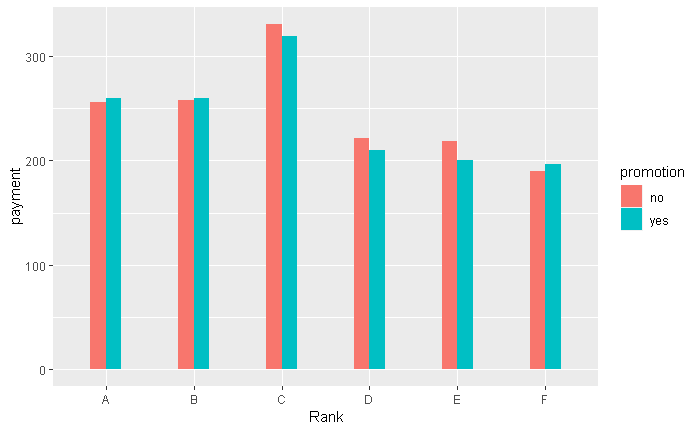

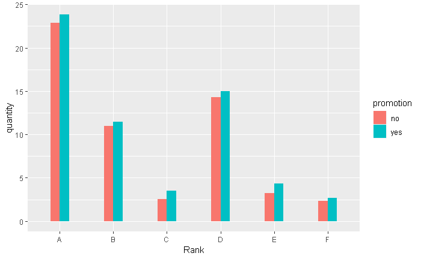

### first_info

```r
##two-way ANOVA
ANOV <- aov_ez(id="MemberId",dv="Mean_Payment",first_info,between=c("Rank","ifpro"))
```

```
Converting to factor: Rank, ifpro
Contrasts set to contr.sum for the following variables: Rank, ifpro
```

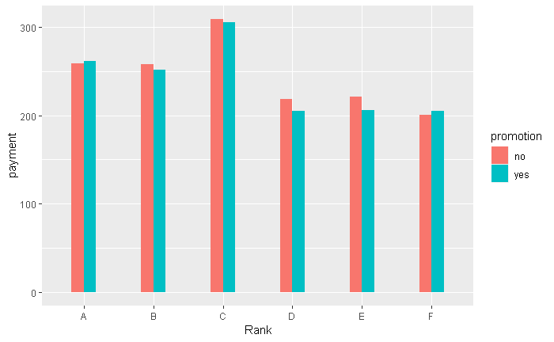

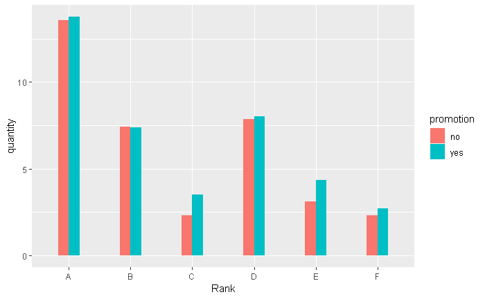

### second_info

```r
summary(ANOV)
```

```
Anova Table (Type 3 tests)

Response: Mean_Payment
           num Df den Df    MSE        F      ges    Pr(>F)
Rank            5 203298 2894.1 6912.384 0.145304 < 2.2e-16 ***
ifpro           1 203298 2894.1   18.402 0.000091 1.789e-05 ***
Rank:ifpro      5 203298 2894.1  103.101 0.002529 < 2.2e-16 ***
---
Signif. codes:  0 ‘***’ 0.001 ‘**’ 0.01 ‘*’ 0.05 ‘.’ 0.1 ‘ ’ 1
```

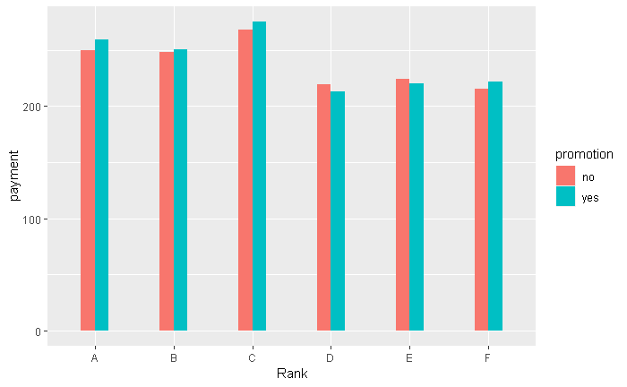

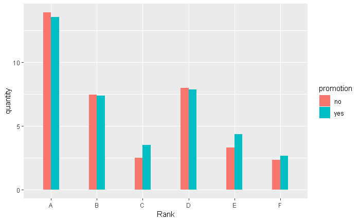

### third_info

```r
summary(ANOV)
```

```
Anova Table (Type 3 tests)

Response: Mean_Payment
           num Df den Df    MSE        F      ges  Pr(>F)
Rank            5 109417 2222.5 2997.818 0.120485 < 2e-16 ***
ifpro           1 109417 2222.5   13.740 0.000126 0.00021 ***
Rank:ifpro      5 109417 2222.5   48.958 0.002232 < 2e-16 ***
---
Signif. codes:  0 ‘***’ 0.001 ‘**’ 0.01 ‘*’ 0.05 ‘.’ 0.1 ‘ ’ 1
```

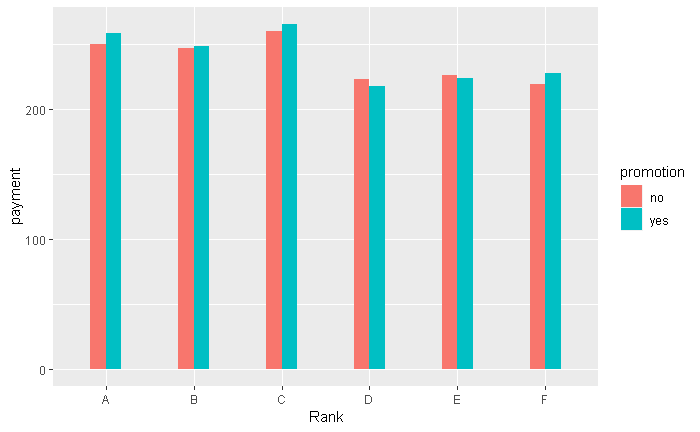

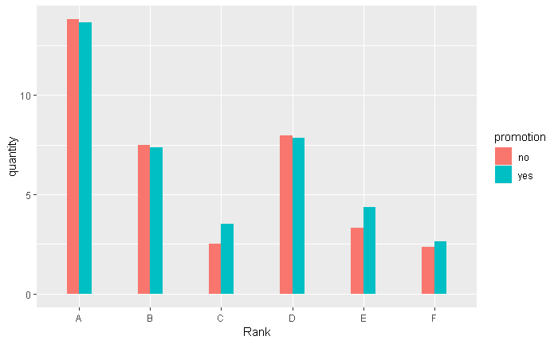

### fourth_info

```
Anova Table (Type 3 tests)

Response: Mean_Payment
           num Df den Df    MSE         F      ges  Pr(>F)
Rank            5  66393 1917.8 1580.2686 0.106352 < 2e-16 ***
ifpro           1  66393 1917.8    4.4495 0.000067 0.03491 *
Rank:ifpro      5  66393 1917.8   31.2954 0.002351 < 2e-16 ***
---
Signif. codes:  0 ‘***’ 0.001 ‘**’ 0.01 ‘*’ 0.05 ‘.’ 0.1 ‘ ’ 1
```

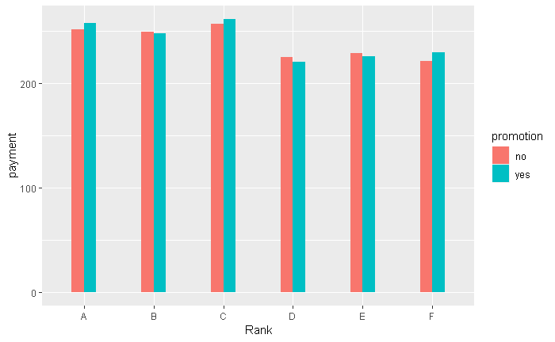

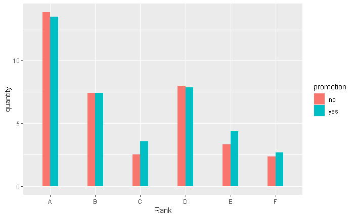

### fifth_info

```r
fifth_info <- fifth_info[,-c(1,3)] %>%
  mutate(ifpro = if_else(PromotionDiscount != 0, 1 , 0),
         ifecou = if_else(ECouponDiscount != 0 , 1, 0))

##two-way ANOVA
ANOV <- aov_ez(id="MemberId",dv="Mean_Payment",fifth_info,between=c("Rank","ifpro"))
summary(ANOV)
```

[output not shown]

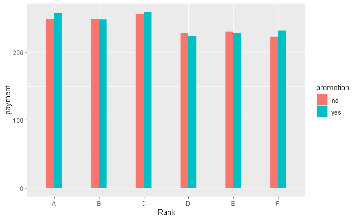

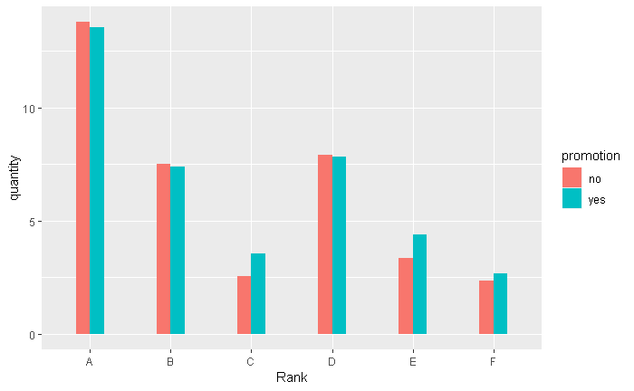

#### 從PART1 的結果可以略看出隨著消費次數的增加，不同組別的平均購買總金額會越來越接近，之後會再把所有組別一起做整合後分析

## EDA to see whether some type of promotion was used more by some group

```r
ANOV <- aov(任選優惠價~Rank, data = god_info1)
summary(ANOV)
```

[output not shown]

```r
god_info %>%
  group_by(Rank)%>%
  summarise(任選優惠價 = mean(任選優惠價),
            滿額折現 = mean(滿額折現),
            滿件打折 = mean(滿件打折),
            滿額贈 = mean(滿額贈))%>%
  gather(key = key, value= value, 任選優惠價, 滿額折現,滿件打折,滿額贈) %>%
  ggplot(aes(x=Rank, y=value,fill=as.factor(key)))+
    geom_bar(stat="identity",width=0.35)
```

[output not shown]

# PART 2

## 取出orders中我們認為可能有意義的特徵變相

```r
ORDERS <- ORDERS[,c(4,5,6,7,8,9,10,18,22,25,26)]
ORDERS <- ORDERS %>%
  subset(IsMajor==TRUE) %>%
  subset(StatusDef=="Finish")
ORDERS <- ORDERS[,-c(5,6,7)]
order_promotion <- merge(order_promotion1,ORDERS ,by="SalesOrderSlaveId",all.y=TRUE)

view(head(first_info,5))
```

## create new df, turn promotion into domi

```r
aa <- order_promotion %>%
  group_by(MemberId,OrderGroupCode)%>%
  summarise(n = n())

a <- order_promotion %>%
  subset(DiscountType == "任選優惠價")%>%
  group_by(MemberId,OrderGroupCode)%>%
  summarise(任選優惠價 = n()) %>%
  #slice(3)

b <- order_promotion %>%
  subset(DiscountType == "滿額贈")%>%
  group_by(MemberId,OrderGroupCode)%>%
  summarise(滿額贈 = n())

c <- order_promotion %>%
  subset(DiscountType == "滿件打折")%>%
  group_by(MemberId,OrderGroupCode)%>%
  summarise(滿件打折 = n())

d <- order_promotion %>%
  subset(DiscountType == "滿額折現")%>%
  group_by(MemberId,OrderGroupCode)%>%
  summarise(滿額折現 = n())

promo <- merge(aa,a[,c(2,3)], by= "OrderGroupCode", all.x= TRUE) %>%
  merge(.,b[,c(2,3)], by= "OrderGroupCode", all.x= TRUE) %>%
  merge(.,c[,c(2,3)], by= "OrderGroupCode", all.x= TRUE) %>%
  merge(.,d[,c(2,3)], by= "OrderGroupCode", all.x= TRUE)
```

```r
# god only
promo_god <- promo %>%
  group_by(MemberId) %>%
  summarize(任選優惠價 = sum(任選優惠價, na.rm = TRUE),
            滿額折現 = sum(滿額折現, na.rm = TRUE),
            滿件打折 = sum(滿件打折, na.rm = TRUE),
            滿額贈 = sum(滿額贈, na.rm = TRUE))

view(head(order_promotion,5))
```

## 將組員做的含有預測rank的資料與他所使用的promotion結合

```r
god_info <- merge(god_info, promo_god , by= "MemberId", all.y = TRUE)
first_info <- merge(first_info, promo_first , by= "MemberId", all.y = TRUE)
second_info <- merge(second_info, promo_second , by= "MemberId", all.y = TRUE)
third_info <- merge(third_info, promo_third , by= "MemberId", all.y = TRUE)
fourth_info <- merge(fourth_info, promo_fourth , by= "MemberId", all.y = TRUE)
fifth_info <- merge(fifth_info, promo_fifth , by= "MemberId", all.y = TRUE)

order_promotion$date = strftime(order_promotion$SalesOrderSlaveDateTime,format="%Y-%m-%d")
order_promotion <- order_promotion[,-c(20)]

promo <-order_promotion[,-c(1,2,3,12,13,14,15,7,8,9,10,11,16,17)]
promo$date <- as.Date(promo$date, "%Y-%m-%d")

promo <- promo %>%
  group_by(MemberId, OrderGroupCode) %>%
  arrange(.$date)%>%
  slice(1)

view(head(promo,1000))
```

```r
a <- promo%>%
  group_by(MemberId) %>%
  slice(1)
```

## 將上述資料再結合orders中的其他消費特徵

|  | MemberId | Rank | ECouponId | ECouponDiscount | PromotionDiscount | Quantity | UnitPriceGroup_(0.0, 160.0] | UnitPriceGroup_(160.0, 320.0] | UnitPriceGroup_(320.0, 480.0] | UnitPriceGroup_(480.0, 640.0] | UnitPriceGroup_(640.0, 3500.0] | Mean_Payment | 任選優惠價 | 滿額折現 | 滿件打折 | 滿額贈 | ifpro | ifecou |
| --- | --- | --- | --- | --- | --- | --- | --- | --- | --- | --- | --- | --- | --- | --- | --- | --- | --- | --- |
| 1 | 1362 | E | 0 | 0 | 0 | 4 | 2 | 2 | 0 | 0 | 0 | 147.7500 | 0 | 0 | 0 | 0 | 0 | 0 |
| 2 | 1384 | D | 0 | 0 | 0 | 6 | 1 | 2 | 2 | 1 | 0 | 311.3333 | 0 | 0 | 2 | 0 | 0 | 0 |
| 3 | 1391 | D | 7449 | -26 | 0 | 23 | 1 | 14 | 7 | 1 | 0 | 243.9130 | 0 | 4 | 10 | 16 | 0 | 1 |
| 4 | 1400 | C | 0 | 0 | 0 | 2 | 0 | 0 | 2 | 0 | 0 | 399.0000 | 0 | 0 | 0 | 0 | 0 | 0 |
| 5 | 1423 | F | 0 | 0 | 0 | 3 | 2 | 1 | 0 | 0 | 0 | 136.5000 | 0 | 0 | 0 | 0 | 0 | 0 |
| 6 | 1448 | D | 0 | 0 | -100 | 29 | 2 | 20 | 6 | 1 | 0 | 257.0000 | 4 | 6 | 0 | 0 | 1 | 0 |

## PART 3 (to be continued….)

#### 目前以將所需用到的特徵值的資料處理好，希望透過PCA降維找出一群同組內且相近特徵值的人，再看看他們後續的消費行為有無差異，例如我們預期有使用PROMOTION與ECOUPON的人會有較高的消費金額，即PART3的部分